# Risk Factor Analysis

## Outcome Variable

**Outcome Variable:** y_rate_haz

## Predictor Variables

**Intervention Variable:** nhh

**Adjustment Set:**

- arm
- W_mage
- meducyrs
- feducyrs
- W_mhtcm
- W_mwtkg
- W_mbmi
- W_nrooms
- trth2o
- cleanck
- impfloor
- impsan
- safeh20
- delta_W_mage
- delta_meducyrs
- delta_feducyrs
- delta_W_mhtcm
- delta_W_mwtkg
- delta_W_mbmi
- delta_W_nrooms
- delta_trth2o
- delta_cleanck
- delta_impfloor
- delta_impsan
- delta_safeh20

## Stratifying Variables

The analysis was stratified on these variable(s):

- agecat
- studyid
- country

## Data Summary

| agecat | studyid | country | nhh | n_cell | n |
| --- | --- | --- | --- | --- | --- |
| 0-3 months | ki1017093-NIH-Birth | BANGLADESH | 3 or less | 101 | 566 |
| 0-3 months | ki1017093-NIH-Birth | BANGLADESH | 4-5 | 239 | 566 |
| 0-3 months | ki1017093-NIH-Birth | BANGLADESH | 6-7 | 132 | 566 |
| 0-3 months | ki1017093-NIH-Birth | BANGLADESH | 8+ | 94 | 566 |
| 0-3 months | ki1017093b-PROVIDE | BANGLADESH | 3 or less | 123 | 634 |
| 0-3 months | ki1017093b-PROVIDE | BANGLADESH | 4-5 | 291 | 634 |
| 0-3 months | ki1017093b-PROVIDE | BANGLADESH | 6-7 | 135 | 634 |
| 0-3 months | ki1017093b-PROVIDE | BANGLADESH | 8+ | 85 | 634 |
| 0-3 months | ki1017093c-NIH-Crypto | BANGLADESH | 3 or less | 107 | 720 |
| 0-3 months | ki1017093c-NIH-Crypto | BANGLADESH | 4-5 | 324 | 720 |
| 0-3 months | ki1017093c-NIH-Crypto | BANGLADESH | 6-7 | 169 | 720 |
| 0-3 months | ki1017093c-NIH-Crypto | BANGLADESH | 8+ | 120 | 720 |
| 0-3 months | ki1000108-IRC | INDIA | 3 or less | 53 | 377 |
| 0-3 months | ki1000108-IRC | INDIA | 4-5 | 146 | 377 |
| 0-3 months | ki1000108-IRC | INDIA | 6-7 | 99 | 377 |
| 0-3 months | ki1000108-IRC | INDIA | 8+ | 79 | 377 |
| 3-6 months | ki1017093-NIH-Birth | BANGLADESH | 3 or less | 89 | 523 |
| 3-6 months | ki1017093-NIH-Birth | BANGLADESH | 4-5 | 223 | 523 |
| 3-6 months | ki1017093-NIH-Birth | BANGLADESH | 6-7 | 126 | 523 |
| 3-6 months | ki1017093-NIH-Birth | BANGLADESH | 8+ | 85 | 523 |
| 3-6 months | ki1017093b-PROVIDE | BANGLADESH | 3 or less | 102 | 574 |
| 3-6 months | ki1017093b-PROVIDE | BANGLADESH | 4-5 | 270 | 574 |
| 3-6 months | ki1017093b-PROVIDE | BANGLADESH | 6-7 | 124 | 574 |
| 3-6 months | ki1017093b-PROVIDE | BANGLADESH | 8+ | 78 | 574 |
| 3-6 months | ki1017093c-NIH-Crypto | BANGLADESH | 3 or less | 101 | 695 |
| 3-6 months | ki1017093c-NIH-Crypto | BANGLADESH | 4-5 | 316 | 695 |
| 3-6 months | ki1017093c-NIH-Crypto | BANGLADESH | 6-7 | 163 | 695 |
| 3-6 months | ki1017093c-NIH-Crypto | BANGLADESH | 8+ | 115 | 695 |
| 3-6 months | ki1000108-IRC | INDIA | 3 or less | 57 | 397 |
| 3-6 months | ki1000108-IRC | INDIA | 4-5 | 154 | 397 |
| 3-6 months | ki1000108-IRC | INDIA | 6-7 | 103 | 397 |
| 3-6 months | ki1000108-IRC | INDIA | 8+ | 83 | 397 |
| 6-12 months | ki1017093-NIH-Birth | BANGLADESH | 3 or less | 87 | 482 |
| 6-12 months | ki1017093-NIH-Birth | BANGLADESH | 4-5 | 202 | 482 |
| 6-12 months | ki1017093-NIH-Birth | BANGLADESH | 6-7 | 112 | 482 |
| 6-12 months | ki1017093-NIH-Birth | BANGLADESH | 8+ | 81 | 482 |
| 6-12 months | ki1017093b-PROVIDE | BANGLADESH | 3 or less | 97 | 545 |
| 6-12 months | ki1017093b-PROVIDE | BANGLADESH | 4-5 | 258 | 545 |
| 6-12 months | ki1017093b-PROVIDE | BANGLADESH | 6-7 | 114 | 545 |
| 6-12 months | ki1017093b-PROVIDE | BANGLADESH | 8+ | 76 | 545 |
| 6-12 months | ki1017093c-NIH-Crypto | BANGLADESH | 3 or less | 95 | 676 |
| 6-12 months | ki1017093c-NIH-Crypto | BANGLADESH | 4-5 | 307 | 676 |
| 6-12 months | ki1017093c-NIH-Crypto | BANGLADESH | 6-7 | 164 | 676 |
| 6-12 months | ki1017093c-NIH-Crypto | BANGLADESH | 8+ | 110 | 676 |
| 6-12 months | ki1000108-IRC | INDIA | 3 or less | 57 | 400 |
| 6-12 months | ki1000108-IRC | INDIA | 4-5 | 154 | 400 |
| 6-12 months | ki1000108-IRC | INDIA | 6-7 | 104 | 400 |
| 6-12 months | ki1000108-IRC | INDIA | 8+ | 85 | 400 |
| 6-12 months | ki1000304b-SAS-FoodSuppl | INDIA | 3 or less | 26 | 332 |
| 6-12 months | ki1000304b-SAS-FoodSuppl | INDIA | 4-5 | 146 | 332 |
| 6-12 months | ki1000304b-SAS-FoodSuppl | INDIA | 6-7 | 106 | 332 |
| 6-12 months | ki1000304b-SAS-FoodSuppl | INDIA | 8+ | 54 | 332 |
| 6-12 months | ki1148112-LCNI-5 | MALAWI | 3 or less | 119 | 430 |
| 6-12 months | ki1148112-LCNI-5 | MALAWI | 4-5 | 183 | 430 |
| 6-12 months | ki1148112-LCNI-5 | MALAWI | 6-7 | 95 | 430 |
| 6-12 months | ki1148112-LCNI-5 | MALAWI | 8+ | 33 | 430 |
| 12-24 months | ki1017093-NIH-Birth | BANGLADESH | 3 or less | 74 | 421 |
| 12-24 months | ki1017093-NIH-Birth | BANGLADESH | 4-5 | 181 | 421 |
| 12-24 months | ki1017093-NIH-Birth | BANGLADESH | 6-7 | 97 | 421 |
| 12-24 months | ki1017093-NIH-Birth | BANGLADESH | 8+ | 69 | 421 |
| 12-24 months | ki1017093b-PROVIDE | BANGLADESH | 3 or less | 86 | 458 |
| 12-24 months | ki1017093b-PROVIDE | BANGLADESH | 4-5 | 213 | 458 |
| 12-24 months | ki1017093b-PROVIDE | BANGLADESH | 6-7 | 96 | 458 |
| 12-24 months | ki1017093b-PROVIDE | BANGLADESH | 8+ | 63 | 458 |
| 12-24 months | ki1017093c-NIH-Crypto | BANGLADESH | 3 or less | 68 | 495 |
| 12-24 months | ki1017093c-NIH-Crypto | BANGLADESH | 4-5 | 224 | 495 |
| 12-24 months | ki1017093c-NIH-Crypto | BANGLADESH | 6-7 | 125 | 495 |
| 12-24 months | ki1017093c-NIH-Crypto | BANGLADESH | 8+ | 78 | 495 |
| 12-24 months | ki1000108-IRC | INDIA | 3 or less | 57 | 396 |
| 12-24 months | ki1000108-IRC | INDIA | 4-5 | 151 | 396 |
| 12-24 months | ki1000108-IRC | INDIA | 6-7 | 103 | 396 |
| 12-24 months | ki1000108-IRC | INDIA | 8+ | 85 | 396 |
| 12-24 months | ki1148112-LCNI-5 | MALAWI | 3 or less | 89 | 307 |
| 12-24 months | ki1148112-LCNI-5 | MALAWI | 4-5 | 130 | 307 |
| 12-24 months | ki1148112-LCNI-5 | MALAWI | 6-7 | 64 | 307 |
| 12-24 months | ki1148112-LCNI-5 | MALAWI | 8+ | 24 | 307 |

The following strata were considered:

- agecat: 0-3 months, studyid: ki1000108-IRC, country: INDIA
- agecat: 0-3 months, studyid: ki1017093-NIH-Birth, country: BANGLADESH
- agecat: 0-3 months, studyid: ki1017093b-PROVIDE, country: BANGLADESH
- agecat: 0-3 months, studyid: ki1017093c-NIH-Crypto, country: BANGLADESH
- agecat: 12-24 months, studyid: ki1000108-IRC, country: INDIA
- agecat: 12-24 months, studyid: ki1017093-NIH-Birth, country: BANGLADESH
- agecat: 12-24 months, studyid: ki1017093b-PROVIDE, country: BANGLADESH
- agecat: 12-24 months, studyid: ki1017093c-NIH-Crypto, country: BANGLADESH
- agecat: 12-24 months, studyid: ki1148112-LCNI-5, country: MALAWI
- agecat: 3-6 months, studyid: ki1000108-IRC, country: INDIA
- agecat: 3-6 months, studyid: ki1017093-NIH-Birth, country: BANGLADESH
- agecat: 3-6 months, studyid: ki1017093b-PROVIDE, country: BANGLADESH
- agecat: 3-6 months, studyid: ki1017093c-NIH-Crypto, country: BANGLADESH
- agecat: 6-12 months, studyid: ki1000108-IRC, country: INDIA
- agecat: 6-12 months, studyid: ki1000304b-SAS-FoodSuppl, country: INDIA
- agecat: 6-12 months, studyid: ki1017093-NIH-Birth, country: BANGLADESH
- agecat: 6-12 months, studyid: ki1017093b-PROVIDE, country: BANGLADESH
- agecat: 6-12 months, studyid: ki1017093c-NIH-Crypto, country: BANGLADESH
- agecat: 6-12 months, studyid: ki1148112-LCNI-5, country: MALAWI

## Methods Detail

We’re interested in the causal parameters $E[Y_a]$ for all values of $a \in \mathcal{A}$. These parameters represent the mean outcome if, possibly contrary to fact, we intervened to set all units to have $A=a$. Under the randomization and positivity assumptions, these are identified by the statistical parameters $\psi_a=E_W[E_{Y|A,W}(Y|A=a,W)]$. In addition, we’re interested in the mean of $Y$, $E[Y]$ under no intervention (the observed mean). We will estimate these parameters by using SuperLearner to fit the relevant likelihood factors – $E_{Y|A,W}(Y|A=a,W)$ and $p(A=a|W)$, and then updating our likelihood fit using a joint TMLE.

For unadjusted analyses ($W=\{\}$), initial likelihoods were estimated using Lrnr_glm to estimate the simple $E(Y|A)$ and Lrnr_mean to estimate $p(A)$. For adjusted analyses, a small library containing Lrnr_glmnet, Lrnr_xgboost, and Lrnr_mean was used.

# Results Detail

## Results Plots

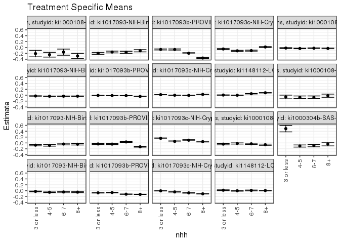

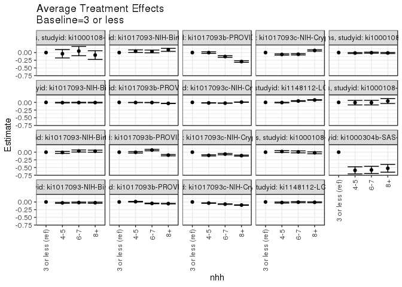

## Results Table

### Parameter: TSM

| agecat | studyid | country | intervention_level | baseline_level | estimate | ci_lower | ci_upper |
| --- | --- | --- | --- | --- | --- | --- | --- |
| 0-3 months | ki1000108-IRC | INDIA | 3 or less | NA | -0.2083745 | -0.3190550 | -0.0976941 |
| 0-3 months | ki1000108-IRC | INDIA | 4-5 | NA | -0.2463654 | -0.3271874 | -0.1655434 |
| 0-3 months | ki1000108-IRC | INDIA | 6-7 | NA | -0.1594416 | -0.2636193 | -0.0552639 |
| 0-3 months | ki1000108-IRC | INDIA | 8+ | NA | -0.2895780 | -0.3787819 | -0.2003741 |
| 0-3 months | ki1017093-NIH-Birth | BANGLADESH | 3 or less | NA | -0.2007952 | -0.2340492 | -0.1675411 |
| 0-3 months | ki1017093-NIH-Birth | BANGLADESH | 4-5 | NA | -0.1548499 | -0.1846749 | -0.1250249 |
| 0-3 months | ki1017093-NIH-Birth | BANGLADESH | 6-7 | NA | -0.1644352 | -0.1996935 | -0.1291769 |
| 0-3 months | ki1017093-NIH-Birth | BANGLADESH | 8+ | NA | -0.1110619 | -0.1497893 | -0.0723345 |
| 0-3 months | ki1017093b-PROVIDE | BANGLADESH | 3 or less | NA | -0.0669086 | -0.0846298 | -0.0491875 |
| 0-3 months | ki1017093b-PROVIDE | BANGLADESH | 4-5 | NA | -0.0682859 | -0.0879520 | -0.0486199 |
| 0-3 months | ki1017093b-PROVIDE | BANGLADESH | 6-7 | NA | -0.1962219 | -0.2158411 | -0.1766027 |
| 0-3 months | ki1017093b-PROVIDE | BANGLADESH | 8+ | NA | -0.3588786 | -0.3774321 | -0.3403251 |
| 0-3 months | ki1017093c-NIH-Crypto | BANGLADESH | 3 or less | NA | -0.0518260 | -0.0674540 | -0.0361980 |
| 0-3 months | ki1017093c-NIH-Crypto | BANGLADESH | 4-5 | NA | -0.1142617 | -0.1314444 | -0.0970791 |
| 0-3 months | ki1017093c-NIH-Crypto | BANGLADESH | 6-7 | NA | -0.1071272 | -0.1248470 | -0.0894074 |
| 0-3 months | ki1017093c-NIH-Crypto | BANGLADESH | 8+ | NA | 0.0167753 | 0.0013363 | 0.0322143 |
| 3-6 months | ki1000108-IRC | INDIA | 3 or less | NA | -0.0598112 | -0.1224003 | 0.0027780 |
| 3-6 months | ki1000108-IRC | INDIA | 4-5 | NA | -0.0686072 | -0.1111203 | -0.0260941 |
| 3-6 months | ki1000108-IRC | INDIA | 6-7 | NA | -0.0682720 | -0.1110085 | -0.0255355 |
| 3-6 months | ki1000108-IRC | INDIA | 8+ | NA | -0.0165544 | -0.0701642 | 0.0370555 |
| 3-6 months | ki1017093-NIH-Birth | BANGLADESH | 3 or less | NA | -0.0752245 | -0.0975387 | -0.0529103 |
| 3-6 months | ki1017093-NIH-Birth | BANGLADESH | 4-5 | NA | -0.0829969 | -0.1087894 | -0.0572043 |
| 3-6 months | ki1017093-NIH-Birth | BANGLADESH | 6-7 | NA | -0.0376085 | -0.0656967 | -0.0095203 |
| 3-6 months | ki1017093-NIH-Birth | BANGLADESH | 8+ | NA | -0.0434889 | -0.0703920 | -0.0165857 |
| 3-6 months | ki1017093b-PROVIDE | BANGLADESH | 3 or less | NA | -0.0350542 | -0.0531365 | -0.0169718 |
| 3-6 months | ki1017093b-PROVIDE | BANGLADESH | 4-5 | NA | -0.0396726 | -0.0559784 | -0.0233668 |
| 3-6 months | ki1017093b-PROVIDE | BANGLADESH | 6-7 | NA | 0.0342502 | 0.0177890 | 0.0507113 |
| 3-6 months | ki1017093b-PROVIDE | BANGLADESH | 8+ | NA | -0.1320245 | -0.1436741 | -0.1203750 |
| 3-6 months | ki1017093c-NIH-Crypto | BANGLADESH | 3 or less | NA | 0.1569858 | 0.1429979 | 0.1709737 |
| 3-6 months | ki1017093c-NIH-Crypto | BANGLADESH | 4-5 | NA | 0.0528947 | 0.0363421 | 0.0694473 |
| 3-6 months | ki1017093c-NIH-Crypto | BANGLADESH | 6-7 | NA | 0.0938549 | 0.0751350 | 0.1125747 |
| 3-6 months | ki1017093c-NIH-Crypto | BANGLADESH | 8+ | NA | 0.0446461 | 0.0320597 | 0.0572326 |
| 6-12 months | ki1000108-IRC | INDIA | 3 or less | NA | -0.0398197 | -0.0632239 | -0.0164156 |
| 6-12 months | ki1000108-IRC | INDIA | 4-5 | NA | -0.0180544 | -0.0380581 | 0.0019494 |
| 6-12 months | ki1000108-IRC | INDIA | 6-7 | NA | -0.0302135 | -0.0515673 | -0.0088596 |
| 6-12 months | ki1000108-IRC | INDIA | 8+ | NA | -0.0606487 | -0.0816623 | -0.0396350 |
| 6-12 months | ki1000304b-SAS-FoodSuppl | INDIA | 3 or less | NA | 0.4864068 | 0.3762122 | 0.5966015 |
| 6-12 months | ki1000304b-SAS-FoodSuppl | INDIA | 4-5 | NA | -0.1046045 | -0.1408254 | -0.0683836 |
| 6-12 months | ki1000304b-SAS-FoodSuppl | INDIA | 6-7 | NA | -0.0918808 | -0.1318529 | -0.0519086 |
| 6-12 months | ki1000304b-SAS-FoodSuppl | INDIA | 8+ | NA | -0.0388175 | -0.1000221 | 0.0223872 |
| 6-12 months | ki1017093-NIH-Birth | BANGLADESH | 3 or less | NA | -0.0252153 | -0.0371128 | -0.0133179 |
| 6-12 months | ki1017093-NIH-Birth | BANGLADESH | 4-5 | NA | -0.0542430 | -0.0656306 | -0.0428554 |
| 6-12 months | ki1017093-NIH-Birth | BANGLADESH | 6-7 | NA | -0.0440359 | -0.0551020 | -0.0329699 |
| 6-12 months | ki1017093-NIH-Birth | BANGLADESH | 8+ | NA | -0.0501315 | -0.0656078 | -0.0346552 |
| 6-12 months | ki1017093b-PROVIDE | BANGLADESH | 3 or less | NA | -0.0726218 | -0.0794395 | -0.0658040 |
| 6-12 months | ki1017093b-PROVIDE | BANGLADESH | 4-5 | NA | -0.0628799 | -0.0700942 | -0.0556656 |
| 6-12 months | ki1017093b-PROVIDE | BANGLADESH | 6-7 | NA | -0.1198296 | -0.1272684 | -0.1123908 |
| 6-12 months | ki1017093b-PROVIDE | BANGLADESH | 8+ | NA | -0.1264397 | -0.1318353 | -0.1210441 |
| 6-12 months | ki1017093c-NIH-Crypto | BANGLADESH | 3 or less | NA | -0.0055633 | -0.0111928 | 0.0000661 |
| 6-12 months | ki1017093c-NIH-Crypto | BANGLADESH | 4-5 | NA | -0.0421423 | -0.0491757 | -0.0351088 |
| 6-12 months | ki1017093c-NIH-Crypto | BANGLADESH | 6-7 | NA | -0.0753729 | -0.0836217 | -0.0671242 |
| 6-12 months | ki1017093c-NIH-Crypto | BANGLADESH | 8+ | NA | -0.1063872 | -0.1126334 | -0.1001410 |
| 6-12 months | ki1148112-LCNI-5 | MALAWI | 3 or less | NA | 0.0151714 | 0.0017178 | 0.0286251 |
| 6-12 months | ki1148112-LCNI-5 | MALAWI | 4-5 | NA | -0.0033953 | -0.0165544 | 0.0097639 |
| 6-12 months | ki1148112-LCNI-5 | MALAWI | 6-7 | NA | 0.0081416 | -0.0052385 | 0.0215218 |
| 6-12 months | ki1148112-LCNI-5 | MALAWI | 8+ | NA | 0.0040400 | -0.0049563 | 0.0130362 |
| 12-24 months | ki1000108-IRC | INDIA | 3 or less | NA | -0.0197208 | -0.0335941 | -0.0058475 |
| 12-24 months | ki1000108-IRC | INDIA | 4-5 | NA | -0.0347117 | -0.0447323 | -0.0246911 |
| 12-24 months | ki1000108-IRC | INDIA | 6-7 | NA | -0.0246287 | -0.0357990 | -0.0134585 |
| 12-24 months | ki1000108-IRC | INDIA | 8+ | NA | -0.0326889 | -0.0447648 | -0.0206130 |
| 12-24 months | ki1017093-NIH-Birth | BANGLADESH | 3 or less | NA | -0.0265085 | -0.0336914 | -0.0193255 |
| 12-24 months | ki1017093-NIH-Birth | BANGLADESH | 4-5 | NA | -0.0353564 | -0.0413294 | -0.0293834 |
| 12-24 months | ki1017093-NIH-Birth | BANGLADESH | 6-7 | NA | -0.0331476 | -0.0392429 | -0.0270522 |
| 12-24 months | ki1017093-NIH-Birth | BANGLADESH | 8+ | NA | -0.0330728 | -0.0405167 | -0.0256289 |
| 12-24 months | ki1017093b-PROVIDE | BANGLADESH | 3 or less | NA | -0.0076493 | -0.0107563 | -0.0045423 |
| 12-24 months | ki1017093b-PROVIDE | BANGLADESH | 4-5 | NA | -0.0129459 | -0.0168526 | -0.0090392 |
| 12-24 months | ki1017093b-PROVIDE | BANGLADESH | 6-7 | NA | -0.0136558 | -0.0168071 | -0.0105044 |
| 12-24 months | ki1017093b-PROVIDE | BANGLADESH | 8+ | NA | -0.0417288 | -0.0446072 | -0.0388504 |
| 12-24 months | ki1017093c-NIH-Crypto | BANGLADESH | 3 or less | NA | 0.0185211 | 0.0152565 | 0.0217857 |
| 12-24 months | ki1017093c-NIH-Crypto | BANGLADESH | 4-5 | NA | -0.0002653 | -0.0044603 | 0.0039296 |
| 12-24 months | ki1017093c-NIH-Crypto | BANGLADESH | 6-7 | NA | -0.0063794 | -0.0103315 | -0.0024274 |
| 12-24 months | ki1017093c-NIH-Crypto | BANGLADESH | 8+ | NA | 0.0266984 | 0.0233639 | 0.0300329 |
| 12-24 months | ki1148112-LCNI-5 | MALAWI | 3 or less | NA | 0.0054524 | -0.0013205 | 0.0122254 |
| 12-24 months | ki1148112-LCNI-5 | MALAWI | 4-5 | NA | -0.0006218 | -0.0073887 | 0.0061452 |
| 12-24 months | ki1148112-LCNI-5 | MALAWI | 6-7 | NA | 0.0500319 | 0.0425299 | 0.0575340 |
| 12-24 months | ki1148112-LCNI-5 | MALAWI | 8+ | NA | 0.0827560 | 0.0756419 | 0.0898702 |

### Parameter: E(Y)

| agecat | studyid | country | intervention_level | baseline_level | estimate | ci_lower | ci_upper |
| --- | --- | --- | --- | --- | --- | --- | --- |
| 0-3 months | ki1000108-IRC | INDIA | NA | NA | -0.2594964 | -0.3154509 | -0.2035418 |
| 0-3 months | ki1017093-NIH-Birth | BANGLADESH | NA | NA | -0.1191165 | -0.1460676 | -0.0921654 |
| 0-3 months | ki1017093b-PROVIDE | BANGLADESH | NA | NA | -0.0413143 | -0.0594662 | -0.0231624 |
| 0-3 months | ki1017093c-NIH-Crypto | BANGLADESH | NA | NA | -0.1220821 | -0.1402761 | -0.1038881 |
| 3-6 months | ki1000108-IRC | INDIA | NA | NA | -0.0518918 | -0.0819849 | -0.0217987 |
| 3-6 months | ki1017093-NIH-Birth | BANGLADESH | NA | NA | -0.0509007 | -0.0730097 | -0.0287917 |
| 3-6 months | ki1017093b-PROVIDE | BANGLADESH | NA | NA | -0.0272428 | -0.0436954 | -0.0107902 |
| 3-6 months | ki1017093c-NIH-Crypto | BANGLADESH | NA | NA | 0.0267740 | 0.0099602 | 0.0435879 |
| 6-12 months | ki1000108-IRC | INDIA | NA | NA | -0.0260151 | -0.0389122 | -0.0131180 |
| 6-12 months | ki1000304b-SAS-FoodSuppl | INDIA | NA | NA | -0.1080113 | -0.1390238 | -0.0769988 |
| 6-12 months | ki1017093-NIH-Birth | BANGLADESH | NA | NA | -0.0530976 | -0.0624028 | -0.0437924 |
| 6-12 months | ki1017093b-PROVIDE | BANGLADESH | NA | NA | -0.0626151 | -0.0695574 | -0.0556729 |
| 6-12 months | ki1017093c-NIH-Crypto | BANGLADESH | NA | NA | -0.0315658 | -0.0388594 | -0.0242722 |
| 6-12 months | ki1148112-LCNI-5 | MALAWI | NA | NA | -0.0067938 | -0.0177737 | 0.0041862 |
| 12-24 months | ki1000108-IRC | INDIA | NA | NA | -0.0317687 | -0.0388357 | -0.0247017 |
| 12-24 months | ki1017093-NIH-Birth | BANGLADESH | NA | NA | -0.0404278 | -0.0450901 | -0.0357656 |
| 12-24 months | ki1017093b-PROVIDE | BANGLADESH | NA | NA | -0.0081718 | -0.0120131 | -0.0043304 |
| 12-24 months | ki1017093c-NIH-Crypto | BANGLADESH | NA | NA | -0.0057326 | -0.0097260 | -0.0017391 |
| 12-24 months | ki1148112-LCNI-5 | MALAWI | NA | NA | -0.0160605 | -0.0218715 | -0.0102495 |

### Parameter: ATE

| agecat | studyid | country | intervention_level | baseline_level | estimate | ci_lower | ci_upper |
| --- | --- | --- | --- | --- | --- | --- | --- |
| 0-3 months | ki1000108-IRC | INDIA | 3 or less | 3 or less | 0.0000000 | 0.0000000 | 0.0000000 |
| 0-3 months | ki1000108-IRC | INDIA | 4-5 | 3 or less | -0.0379909 | -0.1744419 | 0.0984602 |
| 0-3 months | ki1000108-IRC | INDIA | 6-7 | 3 or less | 0.0489329 | -0.1021403 | 0.2000062 |
| 0-3 months | ki1000108-IRC | INDIA | 8+ | 3 or less | -0.0812035 | -0.2229690 | 0.0605621 |
| 0-3 months | ki1017093-NIH-Birth | BANGLADESH | 3 or less | 3 or less | 0.0000000 | 0.0000000 | 0.0000000 |
| 0-3 months | ki1017093-NIH-Birth | BANGLADESH | 4-5 | 3 or less | 0.0459452 | 0.0042528 | 0.0876377 |
| 0-3 months | ki1017093-NIH-Birth | BANGLADESH | 6-7 | 3 or less | 0.0363600 | -0.0091240 | 0.0818439 |
| 0-3 months | ki1017093-NIH-Birth | BANGLADESH | 8+ | 3 or less | 0.0897333 | 0.0404088 | 0.1390577 |
| 0-3 months | ki1017093b-PROVIDE | BANGLADESH | 3 or less | 3 or less | 0.0000000 | 0.0000000 | 0.0000000 |
| 0-3 months | ki1017093b-PROVIDE | BANGLADESH | 4-5 | 3 or less | -0.0013773 | -0.0277955 | 0.0250409 |
| 0-3 months | ki1017093b-PROVIDE | BANGLADESH | 6-7 | 3 or less | -0.1293133 | -0.1560661 | -0.1025605 |
| 0-3 months | ki1017093b-PROVIDE | BANGLADESH | 8+ | 3 or less | -0.2919699 | -0.3184476 | -0.2654923 |
| 0-3 months | ki1017093c-NIH-Crypto | BANGLADESH | 3 or less | 3 or less | 0.0000000 | 0.0000000 | 0.0000000 |
| 0-3 months | ki1017093c-NIH-Crypto | BANGLADESH | 4-5 | 3 or less | -0.0624357 | -0.0838629 | -0.0410085 |
| 0-3 months | ki1017093c-NIH-Crypto | BANGLADESH | 6-7 | 3 or less | -0.0553012 | -0.0776142 | -0.0329881 |
| 0-3 months | ki1017093c-NIH-Crypto | BANGLADESH | 8+ | 3 or less | 0.0686013 | 0.0475768 | 0.0896258 |
| 3-6 months | ki1000108-IRC | INDIA | 3 or less | 3 or less | 0.0000000 | 0.0000000 | 0.0000000 |
| 3-6 months | ki1000108-IRC | INDIA | 4-5 | 3 or less | -0.0087960 | -0.0834561 | 0.0658641 |
| 3-6 months | ki1000108-IRC | INDIA | 6-7 | 3 or less | -0.0084608 | -0.0836744 | 0.0667527 |
| 3-6 months | ki1000108-IRC | INDIA | 8+ | 3 or less | 0.0432568 | -0.0380146 | 0.1245282 |
| 3-6 months | ki1017093-NIH-Birth | BANGLADESH | 3 or less | 3 or less | 0.0000000 | 0.0000000 | 0.0000000 |
| 3-6 months | ki1017093-NIH-Birth | BANGLADESH | 4-5 | 3 or less | -0.0077724 | -0.0394672 | 0.0239224 |
| 3-6 months | ki1017093-NIH-Birth | BANGLADESH | 6-7 | 3 or less | 0.0376160 | 0.0040763 | 0.0711557 |
| 3-6 months | ki1017093-NIH-Birth | BANGLADESH | 8+ | 3 or less | 0.0317356 | -0.0012426 | 0.0647139 |
| 3-6 months | ki1017093b-PROVIDE | BANGLADESH | 3 or less | 3 or less | 0.0000000 | 0.0000000 | 0.0000000 |
| 3-6 months | ki1017093b-PROVIDE | BANGLADESH | 4-5 | 3 or less | -0.0046184 | -0.0288627 | 0.0196259 |
| 3-6 months | ki1017093b-PROVIDE | BANGLADESH | 6-7 | 3 or less | 0.0693043 | 0.0448990 | 0.0937097 |
| 3-6 months | ki1017093b-PROVIDE | BANGLADESH | 8+ | 3 or less | -0.0969704 | -0.1184188 | -0.0755219 |
| 3-6 months | ki1017093c-NIH-Crypto | BANGLADESH | 3 or less | 3 or less | 0.0000000 | 0.0000000 | 0.0000000 |
| 3-6 months | ki1017093c-NIH-Crypto | BANGLADESH | 4-5 | 3 or less | -0.1040911 | -0.1235937 | -0.0845885 |
| 3-6 months | ki1017093c-NIH-Crypto | BANGLADESH | 6-7 | 3 or less | -0.0631309 | -0.0845193 | -0.0417425 |
| 3-6 months | ki1017093c-NIH-Crypto | BANGLADESH | 8+ | 3 or less | -0.1123397 | -0.1300337 | -0.0946456 |
| 6-12 months | ki1000108-IRC | INDIA | 3 or less | 3 or less | 0.0000000 | 0.0000000 | 0.0000000 |
| 6-12 months | ki1000108-IRC | INDIA | 4-5 | 3 or less | 0.0217653 | -0.0090589 | 0.0525896 |
| 6-12 months | ki1000108-IRC | INDIA | 6-7 | 3 or less | 0.0096062 | -0.0220826 | 0.0412951 |
| 6-12 months | ki1000108-IRC | INDIA | 8+ | 3 or less | -0.0208289 | -0.0522293 | 0.0105714 |
| 6-12 months | ki1000304b-SAS-FoodSuppl | INDIA | 3 or less | 3 or less | 0.0000000 | 0.0000000 | 0.0000000 |
| 6-12 months | ki1000304b-SAS-FoodSuppl | INDIA | 4-5 | 3 or less | -0.5910113 | -0.7068624 | -0.4751602 |
| 6-12 months | ki1000304b-SAS-FoodSuppl | INDIA | 6-7 | 3 or less | -0.5782876 | -0.6957042 | -0.4608710 |
| 6-12 months | ki1000304b-SAS-FoodSuppl | INDIA | 8+ | 3 or less | -0.5252243 | -0.6516489 | -0.3987997 |
| 6-12 months | ki1017093-NIH-Birth | BANGLADESH | 3 or less | 3 or less | 0.0000000 | 0.0000000 | 0.0000000 |
| 6-12 months | ki1017093-NIH-Birth | BANGLADESH | 4-5 | 3 or less | -0.0290277 | -0.0454108 | -0.0126446 |
| 6-12 months | ki1017093-NIH-Birth | BANGLADESH | 6-7 | 3 or less | -0.0188206 | -0.0350686 | -0.0025726 |
| 6-12 months | ki1017093-NIH-Birth | BANGLADESH | 8+ | 3 or less | -0.0249162 | -0.0444568 | -0.0053756 |
| 6-12 months | ki1017093b-PROVIDE | BANGLADESH | 3 or less | 3 or less | 0.0000000 | 0.0000000 | 0.0000000 |
| 6-12 months | ki1017093b-PROVIDE | BANGLADESH | 4-5 | 3 or less | 0.0097419 | -0.0001610 | 0.0196447 |
| 6-12 months | ki1017093b-PROVIDE | BANGLADESH | 6-7 | 3 or less | -0.0472078 | -0.0573874 | -0.0370282 |
| 6-12 months | ki1017093b-PROVIDE | BANGLADESH | 8+ | 3 or less | -0.0538179 | -0.0626309 | -0.0450050 |
| 6-12 months | ki1017093c-NIH-Crypto | BANGLADESH | 3 or less | 3 or less | 0.0000000 | 0.0000000 | 0.0000000 |
| 6-12 months | ki1017093c-NIH-Crypto | BANGLADESH | 4-5 | 3 or less | -0.0365789 | -0.0446531 | -0.0285048 |
| 6-12 months | ki1017093c-NIH-Crypto | BANGLADESH | 6-7 | 3 or less | -0.0698096 | -0.0790861 | -0.0605332 |
| 6-12 months | ki1017093c-NIH-Crypto | BANGLADESH | 8+ | 3 or less | -0.1008239 | -0.1085997 | -0.0930480 |
| 6-12 months | ki1148112-LCNI-5 | MALAWI | 3 or less | 3 or less | 0.0000000 | 0.0000000 | 0.0000000 |
| 6-12 months | ki1148112-LCNI-5 | MALAWI | 4-5 | 3 or less | -0.0185667 | -0.0354213 | -0.0017120 |
| 6-12 months | ki1148112-LCNI-5 | MALAWI | 6-7 | 3 or less | -0.0070298 | -0.0244580 | 0.0103985 |
| 6-12 months | ki1148112-LCNI-5 | MALAWI | 8+ | 3 or less | -0.0111315 | -0.0258816 | 0.0036186 |
| 12-24 months | ki1000108-IRC | INDIA | 3 or less | 3 or less | 0.0000000 | 0.0000000 | 0.0000000 |
| 12-24 months | ki1000108-IRC | INDIA | 4-5 | 3 or less | -0.0149909 | -0.0318579 | 0.0018760 |
| 12-24 months | ki1000108-IRC | INDIA | 6-7 | 3 or less | -0.0049080 | -0.0226159 | 0.0127999 |
| 12-24 months | ki1000108-IRC | INDIA | 8+ | 3 or less | -0.0129681 | -0.0311255 | 0.0051892 |
| 12-24 months | ki1017093-NIH-Birth | BANGLADESH | 3 or less | 3 or less | 0.0000000 | 0.0000000 | 0.0000000 |
| 12-24 months | ki1017093-NIH-Birth | BANGLADESH | 4-5 | 3 or less | -0.0088479 | -0.0182063 | 0.0005105 |
| 12-24 months | ki1017093-NIH-Birth | BANGLADESH | 6-7 | 3 or less | -0.0066391 | -0.0160693 | 0.0027911 |
| 12-24 months | ki1017093-NIH-Birth | BANGLADESH | 8+ | 3 or less | -0.0065644 | -0.0168944 | 0.0037656 |
| 12-24 months | ki1017093b-PROVIDE | BANGLADESH | 3 or less | 3 or less | 0.0000000 | 0.0000000 | 0.0000000 |
| 12-24 months | ki1017093b-PROVIDE | BANGLADESH | 4-5 | 3 or less | -0.0052966 | -0.0096738 | -0.0009193 |
| 12-24 months | ki1017093b-PROVIDE | BANGLADESH | 6-7 | 3 or less | -0.0060064 | -0.0098814 | -0.0021315 |
| 12-24 months | ki1017093b-PROVIDE | BANGLADESH | 8+ | 3 or less | -0.0340795 | -0.0377044 | -0.0304546 |
| 12-24 months | ki1017093c-NIH-Crypto | BANGLADESH | 3 or less | 3 or less | 0.0000000 | 0.0000000 | 0.0000000 |
| 12-24 months | ki1017093c-NIH-Crypto | BANGLADESH | 4-5 | 3 or less | -0.0187865 | -0.0240610 | -0.0135119 |
| 12-24 months | ki1017093c-NIH-Crypto | BANGLADESH | 6-7 | 3 or less | -0.0249005 | -0.0299821 | -0.0198190 |
| 12-24 months | ki1017093c-NIH-Crypto | BANGLADESH | 8+ | 3 or less | 0.0081773 | 0.0033291 | 0.0130254 |
| 12-24 months | ki1148112-LCNI-5 | MALAWI | 3 or less | 3 or less | 0.0000000 | 0.0000000 | 0.0000000 |
| 12-24 months | ki1148112-LCNI-5 | MALAWI | 4-5 | 3 or less | -0.0060742 | -0.0158641 | 0.0037158 |
| 12-24 months | ki1148112-LCNI-5 | MALAWI | 6-7 | 3 or less | 0.0445795 | 0.0341760 | 0.0549830 |
| 12-24 months | ki1148112-LCNI-5 | MALAWI | 8+ | 3 or less | 0.0773036 | 0.0674807 | 0.0871265 |